# Lab 1 - The Five-Number Summary

Douglas Luke

July 10, 2021

## Introduction

This is the first SNA Lab for the summer workshop. (See *Preparing Your Computer for SNA* for instructions on how to install R, RStudio, and the required datasets.)

This Lab has two goals:

1. Demonstrate the *Notebook* functionality built-in to RStudio.
2. Demonstrate some very basic ways to examine a network using the `statnet` package in R.

First, load the required network and data packages.

```r
library(statnet)
library(UserNetR)
data(Moreno)
```

## Simple visualization

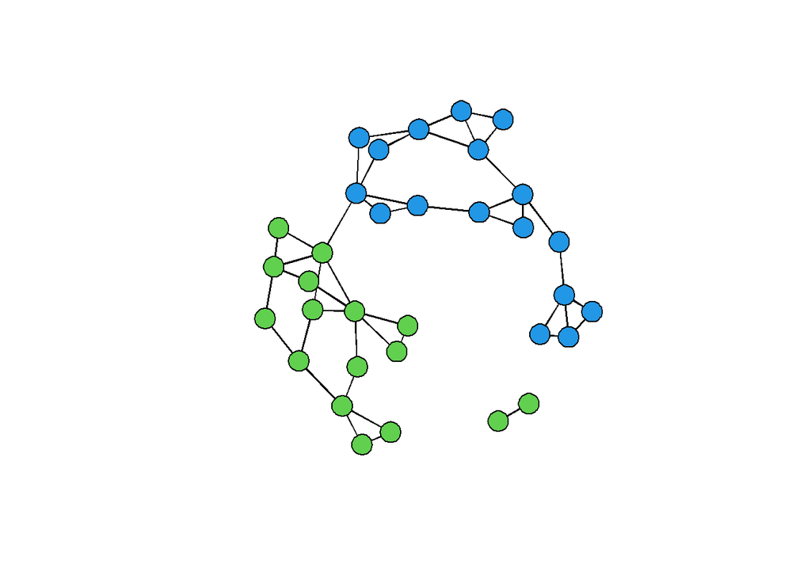

```r
plot(Moreno,
     vertex.col = (Moreno %v% "gender" + 2),
     vertex.cex=3)
```

E: Try changing the number for ‘vertex.cex’ and see what happens when you rerun the code.

## Basic Description

When you have network data, there are usually some basic characteristics of the network that you will interested in.

### Network summary for a statnet object

Most things that R can manipulate (plot, analyze, transform, etc.) are stored as some type of R object. These objects can be examined in a number of ways. You can usually start by calling the *summary()* function on the object that you’re interested in. Here, we can look at the basic information about the Moreno network.

```r
summary(Moreno,print.adj=FALSE)
```

```
## Network attributes:
##   vertices = 33
##   directed = FALSE
##   hyper = FALSE
##   loops = FALSE
##   multiple = FALSE
##   bipartite = FALSE
##  total edges = 46
##    missing edges = 0
##    non-missing edges = 46
##  density = 0.08712121
##
## Vertex attributes:
##
##  gender:
##    numeric valued attribute
##    attribute summary:
##    Min. 1st Qu.  Median    Mean 3rd Qu.    Max.
##   1.000   1.000   2.000   1.515   2.000   2.000
##   vertex.names:
##    character valued attribute
##    33 valid vertex names
##
## No edge attributes
```

E: Try removing the ‘print.adj = F’ part of the command and see if you can figure out what is happening.

### Network size

The most fundamental piece of information about a network is its size. This is the number of nodes (vertices) that are in the network. (Typically, you will already know the size of the network before you even look at the data.)

```r
network.size(Moreno)
```

```
## [1] 33
```

Notice that this information was also included in the network summary above.

### Network density

Possibly the most useful basic descriptive of a network is its density, which is the proportion of observed ties to the total number of possible ties. It is a measure of the *interconnectedness* of the network.

```r
gden(Moreno)
```

```
## [1] 0.08712121
```

### Components

If you examine the previous plot, you can see that the network has two separate groups. Most of the members are connected to each other, but two green dots are connected to each other but not to the larger group. These are called components, and you can see how many are in your network with the following code.

```r
components(Moreno)
```

```
## [1] 2
```

### Diameter

A social network is considered compact if it doesn’t take many hops or connections to get from one node to the furthest away node. The diameter of the network is the distance between the two most distant nodes. The following code is a little complicated, it will be explained later. Note also that this is easier to do in igraph.

```r
lgc <- component.largest(Moreno,result="graph")
gd <- geodist(lgc)
max(gd$gdist)
```

```
## [1] 11
```

### Clustering coefficient

True social networks (e.g., made up by people) often exhibit a tendency towards closure or clustering. One way to assess this is by measuring the network’s transitivity.

```r
gtrans(Moreno,mode="graph")
```

```
## [1] 0.2857143
```

In summary, R allows you to get a quick sense of the important characteristics of any network that is stored as an R network data object.